# Power and unbalanced data

The reality of pre-test/post-test experimental design (particularly if the test is administered on-line) is that you don’t always end up with balanced data. Hopefully, most participants will complete both pre-test and post-test, with only a small number completing one or the other but not both. The traditional approach is to discard the incomplete cases and perform a repeated-measures ANOVA or MANOVA. But what are the options if only a small number of participants present complete cases?

One option would be to consider the experiment as cross-sectional with experimental (post-test) and control (pre-test) groups. However, due to the assumption of independence that this imposes, this means discarding the complete cases. Another approach is to use multi-level modelling, where the assumption of indepedence can be relaxed (providing participants can be identified and included as a random effect). This allows us to use the full data-set, improving power.

Here I present the results of a simulation, where the total number of scores is 500. Of these 150 are from complete cases (*i.e* 75 participants), 140 are pre-test scores, and 210 are post-test scores. Three scenarios are presented: 1. Repeated-measures ANOVA using the 75 complete cases 2. Between-groups t-test on the pre-test and post-test scores, with the 150 non-independent scores discarded 3. Multi-level model with all observations included, and a random intercept for participant.

Two-hundred random data-sets were generated for each fixed effect, and power was estimated for each test (being the proportion of significant p-values calculated at the alpha = .05 level). Effect sizes were estimated (Cohen’s d) for each sample (even though the experimental effect was known).

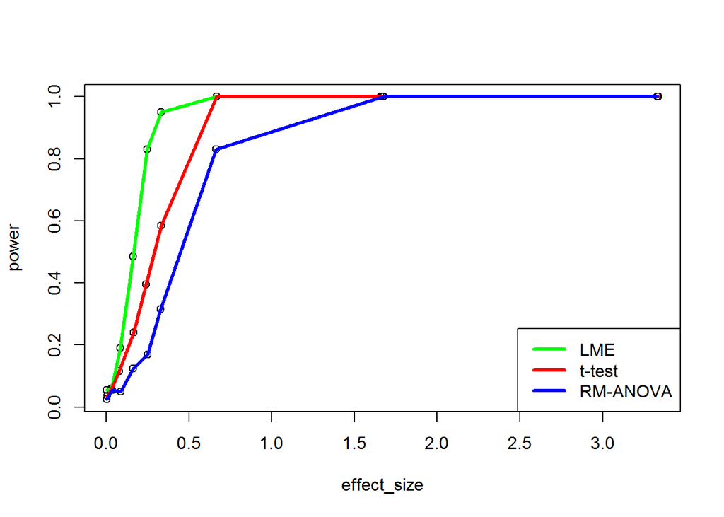